# Rendering

# Output Formats

Quarto provides the following output formats:

- HTML
- PDF
- Typst (way better than LaTex!)
- MS Word (`docx`)
- OpenOffice (`odt`)
- ePub

## How To Render

**1. In RStudio**:

Click the *Render* button OR use the `quarto` R package:

```r
library(quarto)
quarto_render("my-reproducible-manuscript.qmd") # defaults to html
quarto_render("my-reproducible-manuscript.qmd", output_format = "pdf")
```

**2. Terminal**: `quarto render` (`--to [output format]`)

```bash
quarto render
quarto render my-reproducible-manuscript.qmd # defaults to html
quarto render my-reproducible-manuscript.qmd --to pdf
```

## Render Options

Render as an **HTML** document

```yaml
---
title: "Hello Quarto"
author: "JJB + Course"
format: html
---
```

Render as a **PDF**

```yaml
---
title: "Hello Quarto"
author: "JJB + Course"
format: pdf
---
```

Render as a **Word**

```yaml
---
title: "Hello Quarto"
author: "JJB + Course"
format: docx
---
```

## Multi-format Render Options

Render one Quarto document to many output options like **HTML**, **Jupyter Notebook**, **PDF**, and **Word Document**.

```yaml
---
title: "Hello Quarto"
author: "JJB + Course"
format:
  html: default
  ipynb: default # new format!
  pdf: default
  docx: default
---
```

**Note**

Quarto supports many formats include [PowerPoint (PPT)](https://quarto.org/docs/reference/formats/presentations/pptx.html), [Revealjs](https://quarto.org/docs/reference/formats/presentations/revealjs.html), [Beamer](https://quarto.org/docs/reference/formats/presentations/beamer.html), [Rich Text Format (RTF)](https://quarto.org/docs/reference/formats/rtf.html), and on. For details, see [All Formats](https://quarto.org/docs/output-formats/all-formats.html).

**Note**

the *Render* button will not work for multiple formats.

## Journal Formats

Besides default `html`/`pdf`/`docx`, Quarto offers journal templates. See also [Quarto Documentation: Journals](https://quarto.org/docs/journals/).

- `acm`: Association of Computing Machinery (ACM)
- `plos`: Public Library of Science (PLOS)
- `agu`: American Geophysical Union (AGU)
- `elsevier`: Elsevier
- `biophysical-journal`: Biophysical
- `acs`: American Chemical Society (ACS)
- `jss`: Journal of Statistical Software (JSS)

## APA - `apaquarto`

Use a journal template **from the start of your project** (will create a new document):

- In console

```bash
quarto use template quarto-journals/<template-name>
```

For example:

```bash
quarto use template wjschne/apaquarto
```

## APA - `apaquarto`

[figure not shown]

## APA - `apaquarto`

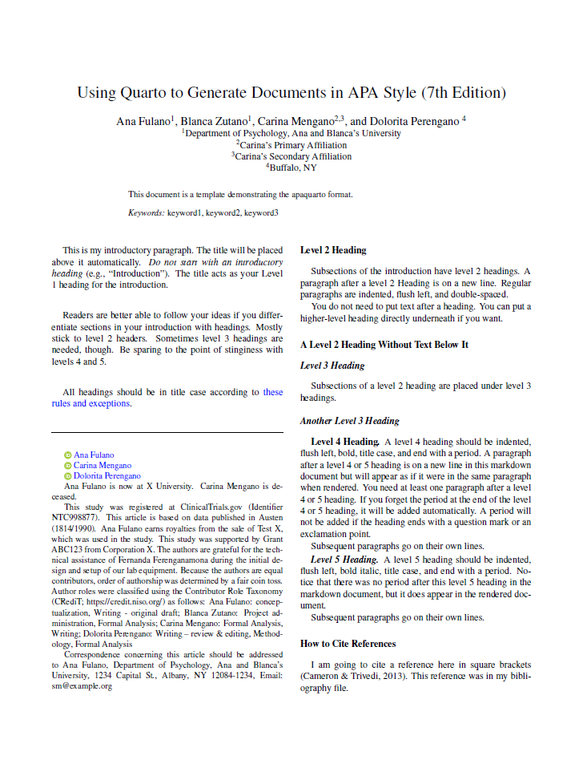

# Publishing

## Sharing Work

- Once you are satisfied with the Quarto document, it’s time to publish your work!
- The publishing step is important as the documents need to be viewed under the guise of a server
- There are multiple options for publishing with Quarto, and we’ll present two of them

## Publish Options

- GitHub Pages
- Quarto Pub
- To make your Quarto document accessible on [GitHub Pages via Quarto](https://quarto.org/docs/publishing/github-pages.html), use the following command in your terminal:

```bash
quarto publish gh-pages
```

- This option is great if you want to share your document through a GitHub Pages website.
- Alternatively, you can publish your Quarto document on [Quarto Pub via Quarto](https://quarto.org/docs/publishing/quarto-pub.html). Use the following command in your terminal:

```bash
quarto publish quarto-pub
```

OR:

- You can find the blue Publishing icon in the following locations:
  - The upper right of the file editor
  - The document viewer when viewing a document
  - The embedded viewer when running a Shiny application
  - The Plots pane
    - Click on icon